# Geog533 Final Exam

Wu_Yanan

**What to submit:**

An **R notebook/html document** that contains the script/output for each question. Use the provided **Geog533_finalExam_template.Rmd** to complete your answers and generate the html document. Filename convention for submissions: lastname_firstname_final.zip. All data needed to complete this exam can be found in the **data.zip**. You have 120 minutes (12:50-2:50 pm) to complete the exam. There will be a 10% penalty per 10 minutes for late submissions. Each question is worth 20 points, with a total of 200 points.

## Question 1 (20 pt.)

The **iris** data set in the **datasets** package contains 150 cases (rows) and 5 variables (columns).

### Question 1(a)

Calculate the mean and variance of **Sepal.Length**.

```r
library(datasets)
data.1 <- iris
mean.1 <-  mean(data.1$Sepal.Length)
mean.1
```

```
[1] 5.843333
```

```r
var.1 <- var(data.1$Sepal.Length)
var.1
```

```
[1] 0.6856935
```

### Question 1(b)

Calculate the covariance and correlation of **Sepal.Length** and **Petal.Length**.

```r
cov.1 <- cov(x = data.1$Sepal.Length, y = data.1$Petal.Length)
cov.1
```

```
[1] 1.274315
```

```r
cor.1 <- cor(x = data.1$Sepal.Length, y = data.1$Petal.Length,method = "pearson")
cor.1
```

```
[1] 0.8717538
```

### Question 1(c)

Create a scatter plot based on **Petal.Length** and **Petal.Width**.

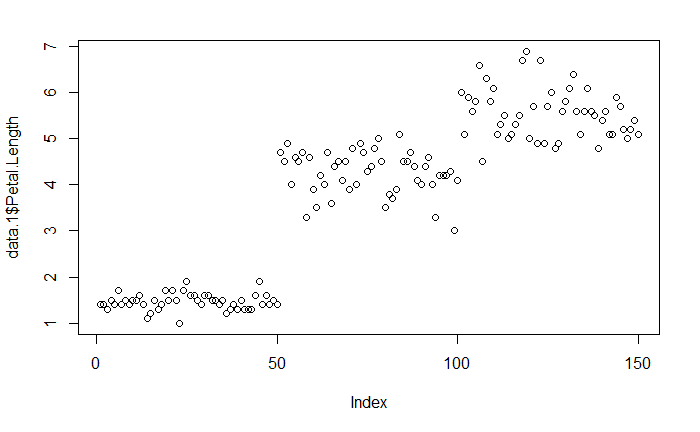

```r
plot(data.1$Petal.Length)
```

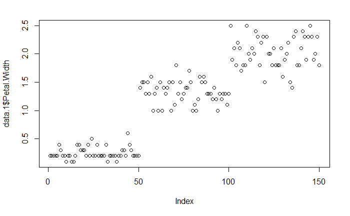

```r
plot(data.1$Petal.Width)
```

### Question 1(d)

Create a pie chart based on **Species**.

### Question 1(e)

There are three species (*setosa, versicolor, and virginica*). Randomly select 20 rows from each species; combine the selected rows as a new dataframe (60 rows); save the remaining 90 rows as a new dataframe.

```r
setosa <- data.1[data.1$Species == "setosa",]
row.1 <- setosa[sample(x = 50, size = 20, replace = F),]
versicolor <- data.1[data.1$Species == "versicolor",]
row.2 <- versicolor[sample(x = 50, size = 20, replace = F),]
virginica <- data.1[data.1$Species == "virginica",]
row.3 <- virginica[sample(x = 50, size = 20, replace = F),]
new.dataframe <- rbind(row.1, row.2, row.3)
rowname <- row.names(new.dataframe)
```

## Question 2 (20 pt.)

On average, there are two bicycle thefts every ten square miles during the course of a month.

### Question 2(a)

What is the probability that there will be no bicycle thefts in a ten square mile area next month?

```r
ppois(0, lambda = 2, lower.tail = T)
```

```
[1] 0.1353353
```

### Question 2(b)

What is the probability that there will be no bicycle thefts in a seven square mile area next month?

```r
ppois(0, lambda = 1.4, lower.tail = T)
```

```
[1] 0.246597
```

### Question 2(c)

What is the probability that there will be at least one bicycle theft in a 20 square mile area next month?

```r
ppois(0, lambda = 20/10, lower.tail = T)
```

```
[1] 0.1353353
```

### Question 2(d)

What is the probability that there will be exactly one bicycle theft in a ten square mile area over the next ten days?

```r
dpois(1, lambda = 60)
```

```
[1] 5.253906e-25
```

### Question 2(e)

What is the probability that there will be more than 20 bicycle thefts in a ten square mile area next year?

```r
ppois(20, lambda = 10, lower.tail = F)
```

```
[1] 0.001588261
```

## Question 3 (20 pt.)

The mean value of annual imports for a country is normally distributed with mean $\mu=30$ million and standard deviation $\sigma=16$ million.

### Question 3(a)

What fraction of years have import values less than 20 million?

```r
pnorm(20, mean = 30, sd = 16, lower.tail = T)
```

```
[1] 0.2659855
```

### Question 3(b)

What fraction of years have import values more than 40 million?

```r
pnorm(40, mean = 30, sd = 16, lower.tail = F)
```

```
[1] 0.2659855
```

### Question 3(c)

What dollar value of imports is exceeded only 5% of the time?

```r
qnorm(p = 0.05, mean = 30, sd = 16)
```

```
[1] 3.682342
```

### Question 3(d)

What fraction of years have import values between 29 and 45 million?

```r
diff(pnorm(c(29,45), mean = 30,sd = 16))
```

```
[1] 0.350667
```

### Question 3(e)

Plot the density function and create the shaded area between 29 and 45 million.

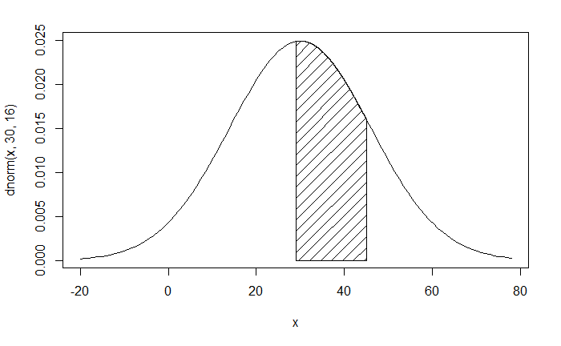

```r
curve(dnorm(x,30,16),from = -20,to = 78)
cord.x <- c(29,seq(29,45,0.01),45)
cord.y <- c(0,dnorm(seq(29,45,0.01),mean = 30,sd = 16),0)
polygon(cord.x,cord.y,density = 10)
```

## Question 4 (20 pt.)

A researcher is interested in differences in travel behavior for residents living in four different regions. From a sample of size 48 (12 in each region), she finds that the mean commuting distance is 5.2 miles, and that the standard deviation is 3.2 miles. Suppose that the standard deviations for each of the four regions are 2.8, 2.9, 3.3, and 3.4.

### Question 4(a)

Fill in the table:

```r
library(MASS)
total <- mvrnorm(n = 48, mu = 5.2, Sigma = 3.2*3.2, empirical = T)
a <-  mvrnorm(n = 12, mu = 5.2,Sigma = 2.8*2.8, empirical = T)
b <- mvrnorm(n = 12, mu = 5.2,Sigma = 2.9*2.9, empirical = T)
c <- mvrnorm(n = 12, mu = 5.2,Sigma = 3.3*3.3, empirical = T)
d <- mvrnorm(n = 12, mu = 5.2,Sigma = 3.4*3.4, empirical = T)
number <- c(a,b,c,d)
class(number)
```

```
[1] "numeric"
```

```r
group <- c(rep("A",12),rep("B",12),rep("C",12),rep("D",12))
biaoge <- data.frame(number,group)
biaoge
```

| number | group |
| --- | --- |
| 6.9105824 | A |
| 11.4046834 | A |
| 7.1392905 | A |
| 4.4467125 | A |
| 2.5869894 | A |
| 3.4135424 | A |
| 2.2303247 | A |
| 6.6006251 | A |
| 5.0184555 | A |
| 1.2752318 | A |

[output cut: 38 more lines]

```r
m <- aov(number~group,data = biaoge)
m
```

```
Call:
   aov(formula = number ~ group, data = biaoge)

Terms:
                group Residuals
Sum of Squares    0.0     425.7
Deg. of Freedom     3        44

Residual standard error: 3.110466
Estimated effects may be unbalanced
```

```r
summa.4 <-  summary(m)
summa.4
```

```
            Df Sum Sq Mean Sq F value Pr(>F)
group        3    0.0   0.000       0      1
Residuals   44  425.7   9.675
```

```r
ssm.1 <-  summa.4[[1]]$`Sum Sq`
```

[output not shown]

### Question 4(b)

State the null and alternative hypotheses.

### Question 4(d)

Do you accept or reject the null hypothesis? Why?

## Question 5 (20 pt.)

The mean number of children among a sample of 15 low-income households is 2.8. The mean number of children among a sample of 19 high-income households is 2.4. The standard deviations for low- and high-income households are found to be 1.6 and 1.7, respectively. Test the hypothesis of no difference against the alternative that high-income households have fewer children. Use $\alpha=0.05$.

```r
a <-  mvrnorm(n = 15, mu = 2.8,Sigma = 1.6*1.6, empirical = T)
b <- mvrnorm(n = 19, mu = 2.4,Sigma = 1.7*1.7, empirical = T)
result <- t.test(a,b)
if (result$p.value){
  print("we accpect the none hypothesize")
}else{
  print("we reject the none hypothesize")
}
```

```
[1] "we accpect the none hypothesize"
```

## Question 6 (20 pt.)

A political geographer is interested in the spatial voting pattern during the last presidential election. She suspects that university professors in her state were more likely than the statewide population to vote for candidate A. The statewide percentage of the population voting for candidate A was 0.38. She takes a random sample of 45 professors in the state, and finds that 20 voted for candidate A. Is there sufficient evidence to support her hypothesis? Use $\alpha=0.05$. What is the p-value?

```r
result.6 <- prop.test(x = 20, n = 45, p = 0.38)
result.6$p.value
```

```
[1] 0.4610709
```

```r
if (result.6$p.value > 0.05){
  print("there is sufficient evidence")
}else{
  print("there is sufficient evidence")
}
```

[output not shown]

## Question 7 (20 pt.)

A researcher conducted a study that examined the relationship between the amount of the students take to complete a test and their scores on the test. The two variables in this study were Time (the number of minutes taken by each student to finish the examination) and Exam score (the number of correct answers for each student, ranging from 0 to 100). The researcher in this study wished to test the null hypothesis that the more time students take to finish an exam, the lower their score on the exam. In other words, there is a negative relationship between Time and Exam score. The data for the 32 students in this study is provided in the **ExamScore.csv**.

### Question 7(a)

State the null and alternative hypotheses.

```r
csv.data <-  read.csv(file = "ExamScore.csv", header = T)
model <-  lm(csv.data$Exam.Score~csv.data$Time)
model
```

```
Call:
lm(formula = csv.data$Exam.Score ~ csv.data$Time)

Coefficients:
  (Intercept)  csv.data$Time
     75.04565       -0.01159
```

```r
summary(model)
```

```
Call:
lm(formula = csv.data$Exam.Score ~ csv.data$Time)

Residuals:
    Min      1Q  Median      3Q     Max
-38.652  -3.658   0.381   7.882  17.441

Coefficients:
              Estimate Std. Error t value Pr(>|t|)
(Intercept)   75.04565    6.42442  11.681 1.09e-12 ***
csv.data$Time -0.01159    0.08850  -0.131    0.897
---
Signif. codes:  0 ‘***’ 0.001 ‘**’ 0.01 ‘*’ 0.05 ‘.’ 0.1 ‘ ’ 1

Residual standard error: 11.81 on 30 degrees of freedom
Multiple R-squared:  0.0005713, Adjusted R-squared:  -0.03274
F-statistic: 0.01715 on 1 and 30 DF,  p-value: 0.8967
```

```r
"more time students take to finish an exam, the lower their score on the exam"
```

```
[1] "more time students take to finish an exam, the lower their score on the exam"
```

```r
"more time students take to finish an exam, the higher their score on the exam"
```

```
[1] "more time students take to finish an exam, the higher their score on the exam"
```

### Question 7(b)

Draw a scatter plot based on Time and Exam score.

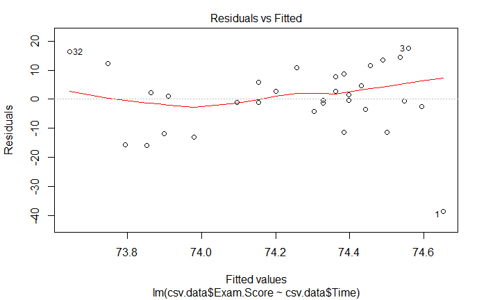

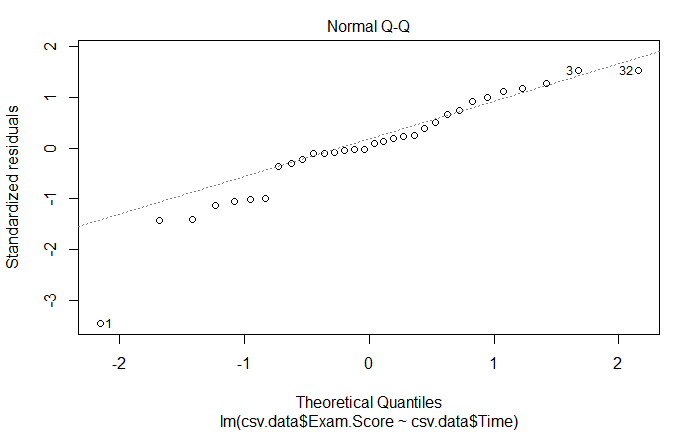

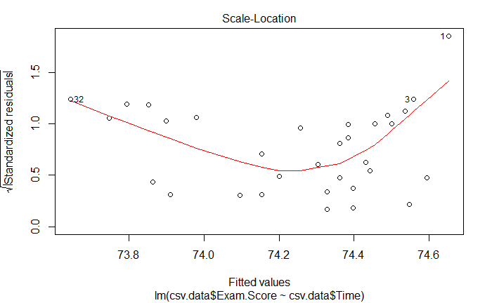

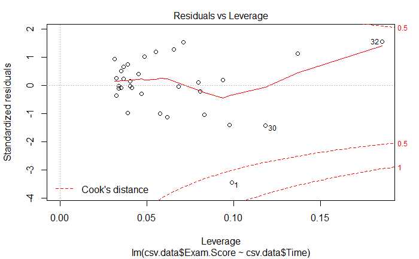

```r
plot(model)
```

### Question 7(c)

State your conclusion.

```r
csv.data <-  read.csv(file = "ExamScore.csv", header = T)
model <-  lm(csv.data$Exam.Score~csv.data$Time)
model
```

```
Call:
lm(formula = csv.data$Exam.Score ~ csv.data$Time)

Coefficients:
  (Intercept)  csv.data$Time
     75.04565       -0.01159
```

```r
zongjie.7 <- summary(model)
pvalue <- 1.09e-12
if (pvalue > 0.05){
  print("more time students take to finish an exam, the lower their score on the exam.")
}else{
  print("more time students take to finish an exam, the higher their score on the exam.")
}
```

[output not shown]

## Question 8 (20 pt.)

Use **us_state.shp** and **NDVI.nc** to complete the following tasks.

### Question 8(a)

Extract and plot the maps of monthly NDVI of the year 2002.

```r
library(sp)
library(raster)
library(ncdf4)
ndvi <- brick("NDVI.nc")
ndvi
```

```
class       : RasterBrick
dimensions  : 360, 720, 259200, 36  (nrow, ncol, ncell, nlayers)
resolution  : 0.5, 0.5  (x, y)
extent      : -180, 180, -90, 90  (xmin, xmax, ymin, ymax)
coord. ref. : +proj=longlat +datum=WGS84 +ellps=WGS84 +towgs84=0,0,0
data source : C:\Users\yyl\Downloads\NDVI.nc
names       : X2000.01.01, X2000.02.01, X2000.03.01, X2000.04.01, X2000.05.01, X2000.06.01, X2000.07.01, X2000.08.01, X2000.09.01, X2000.10.01, X2000.11.01, X2000.12.01, X2001.01.01, X2001.02.01, X2001.03.01, ...
Date        : 2000-01-01, 2002-12-01 (min, max)
varname     : NDVI
```

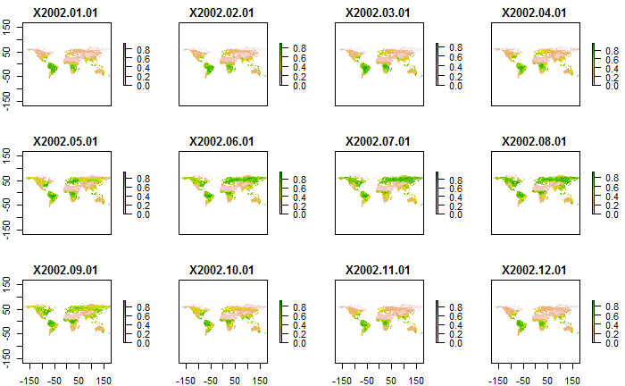

```r
plot(ndvi,25:36)
```

### Question 8(b)

Aggregate the 12 bands of the year 2002 to generate a mean NDVI raster.

```r
ndvi2002 <- ndvi[[25:36]]
ndvi2002
```

```
class       : RasterStack
dimensions  : 360, 720, 259200, 12  (nrow, ncol, ncell, nlayers)
resolution  : 0.5, 0.5  (x, y)
extent      : -180, 180, -90, 90  (xmin, xmax, ymin, ymax)
coord. ref. : +proj=longlat +datum=WGS84 +ellps=WGS84 +towgs84=0,0,0
names       : X2002.01.01, X2002.02.01, X2002.03.01, X2002.04.01, X2002.05.01, X2002.06.01, X2002.07.01, X2002.08.01, X2002.09.01, X2002.10.01, X2002.11.01, X2002.12.01
```

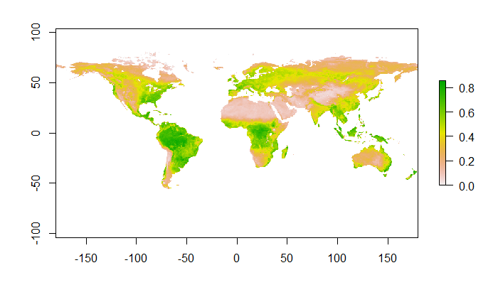

```r
mean.8 <- mean(ndvi2002)
plot(mean.8)
```

### Question 8(c)

Plot the above mean NDVI raster with us_state.shp overlaid on top.

```r
plot(0,type='n',axes=FALSE,ann=FALSE)
```

```r
print(data, newpage = F)
```

[output not shown]

[output cut: 112 more lines]

[output not shown]

```r
if(!require(rgdal)) install.packages("rgdal")
```

[output not shown]

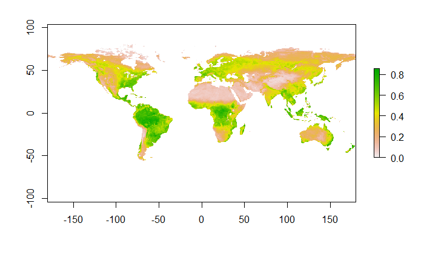

```r
library(rgdal)
land <- readOGR(".", "us_state")
plot(mean.8)
```

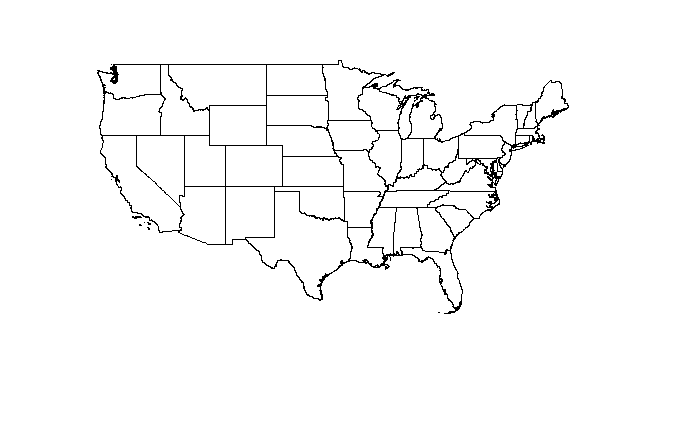

```r
plot(land)
plot(land,add=T)
```

### Question 8(d)

Use us_state.shp as a mask to clip the mean NDVI raster.

### Question 8(e)

Plot and save the above clipped raster.

## Question 9 (20 pt.)

Use the provided **earthquake.txt** to create an interactive map using leaflet. The popup box for each point must show the earthquake information, including Station ID, latitude, longitude, depth, and magnitude. See the map below for example.

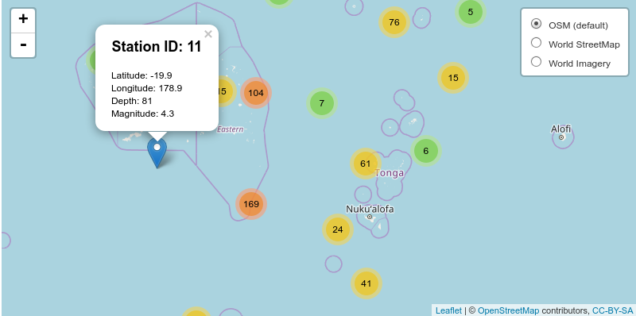

```r
if(!require(leaflet)) install.packages("leaflet")
```

[output not shown]

```r
library(leaflet)
biaoge <- read.csv('earthquakes.csv')
leaflet(data = biaoge, width = "100%") %>%
  addTiles() %>%
  addMarkers(~long, ~lat,popup = ~as.character(mag),label = paste('Magnitude:',biaoge$mag,'longtitude:',biaoge$long,'latitude:',biaoge$lat,'Depth:',biaoge$depth),clusterOptions = markerClusterOptions())
```

[interactive chart not shown]

## Question 10 (20 pt.)

Central Bank prints paper money each year. For each year they need an estimate of how much money to be printed. The decision is based on various economic indicators like GDP, Interest rate, and WPI-based inflation, etc. Use the provided **money.csv** to construct multiple linear regression models.

### Question 10(a)

Construct a multiple linear regression model that uses GDP, Interest_RATE, and WPI as independent variables to predict Money_printed.

```r
money.csv <- read.csv(file = "money.csv", header = T)
model.10 <- lm(money.csv$Money_printed~money.csv$GDP+money.csv$Interest_RATE+money.csv$WPI)
model.10
```

```
Call:
lm(formula = money.csv$Money_printed ~ money.csv$GDP + money.csv$Interest_RATE +
    money.csv$WPI)

Coefficients:
            (Intercept)            money.csv$GDP  money.csv$Interest_RATE
             -1.759e+04                2.975e-01               -1.626e+04
          money.csv$WPI
              2.943e+01
```

```r
summary(model.10)
```

```
Call:
lm(formula = money.csv$Money_printed ~ money.csv$GDP + money.csv$Interest_RATE +
    money.csv$WPI)

Residuals:
   Min     1Q Median     3Q    Max
-46875  -7027   1387  15068  46249

Coefficients:
                          Estimate Std. Error t value Pr(>|t|)
(Intercept)             -1.759e+04  5.052e+04  -0.348  0.73008
money.csv$GDP            2.975e-01  8.787e-02   3.385  0.00195 **
money.csv$Interest_RATE -1.626e+04  2.919e+03  -5.570 4.19e-06 ***
money.csv$WPI            2.943e+01  9.038e+02   0.033  0.97423
---
Signif. codes:  0 ‘***’ 0.001 ‘**’ 0.01 ‘*’ 0.05 ‘.’ 0.1 ‘ ’ 1

Residual standard error: 22770 on 31 degrees of freedom
Multiple R-squared:  0.9848,    Adjusted R-squared:  0.9834
F-statistic: 670.4 on 3 and 31 DF,  p-value: < 2.2e-16
```

### Question 10(b)

Comment on the above regression model. Which independent variable(s) is insignificant?

```r
print("wpi is insiginificant")
```

```
[1] "wpi is insiginificant"
```

### Question 10(c)

If you have an opportunity to improve the regression model, what would you do? Print out the improved regression model, if any.

```r
reduced.model <- step(model.10, direction="backward")
```

```
Start:  AIC=706.09
money.csv$Money_printed ~ money.csv$GDP + money.csv$Interest_RATE +
    money.csv$WPI

                          Df  Sum of Sq        RSS    AIC
- money.csv$WPI            1 5.4988e+05 1.6078e+10 704.09
<none>                                  1.6078e+10 706.09
- money.csv$GDP            1 5.9441e+09 2.2022e+10 715.10
- money.csv$Interest_RATE  1 1.6092e+10 3.2170e+10 728.36

Step:  AIC=704.09
money.csv$Money_printed ~ money.csv$GDP + money.csv$Interest_RATE

                          Df  Sum of Sq        RSS    AIC
<none>                                  1.6078e+10 704.09
- money.csv$Interest_RATE  1 3.3709e+10 4.9787e+10 741.65
- money.csv$GDP            1 9.4827e+11 9.6435e+11 845.38
```

```r
summary(reduced.model)
```

```
Call:
lm(formula = money.csv$Money_printed ~ money.csv$GDP + money.csv$Interest_RATE)

Residuals:
   Min     1Q Median     3Q    Max
-47055  -7168   1432  14998  46008

Coefficients:
                          Estimate Std. Error t value Pr(>|t|)
(Intercept)             -1.906e+04  2.192e+04  -0.870    0.391
money.csv$GDP            3.003e-01  6.913e-03  43.443  < 2e-16 ***
money.csv$Interest_RATE -1.619e+04  1.977e+03  -8.191 2.35e-09 ***
---
Signif. codes:  0 ‘***’ 0.001 ‘**’ 0.01 ‘*’ 0.05 ‘.’ 0.1 ‘ ’ 1

Residual standard error: 22420 on 32 degrees of freedom
Multiple R-squared:  0.9848,    Adjusted R-squared:  0.9839
F-statistic:  1038 on 2 and 32 DF,  p-value: < 2.2e-16
```

### Question 10(d)

Based on the improved regression model, predict how much money should be printed if GDP, Interest_RATE, and WPI are 2800000, 7.1, and 210, respectively.

```r
money.result <- 3.003e-01*2800000-1.619e+04*7.1-1.906e+04
money.result
```

```
[1] 706831
```